# Fear of Missing Out and Social Media Use: Differential Effects of Priming on Attitudes Towards Products

Author: omitted for blind review last change: 07-22-2020

# Sample

# Construct

Attitude toward the product (α = 0.94) was assessed using a nine-item, seven-point semantic differential scale (e.g., “not worth having” = 1 to “worth having” = 7) based on Benedek and Miner (2002).  
We manipulated priming condition by showing participants in the priming condition a screenshot of the product embedded in an Instagram frame prior to viewing the online shop stimulus. Participants in the no priming condition were not exposed to this additional Instagram stimulus.

Degree of participation within Instagram (α = 0.87) was assessed using a six-item, six-point semantic differential scale (e.g. “passive” = 1 to “active” = 6) based on prior research (Bolton, 2013; Schlosser, 2005; Shao, 2009). Fear of missing out (α = 0.84) was assessed using an eight-item, seven-point Likert-type scale (e.g., “I get anxious when I don’t know what my friends are up to”), based on Abel et al. (2016) and Przybylski et al. (2013).  
We assessed several control variables to account for possible confounds. We assessed experience with online shopping (α = 0.89) using a three item, seven-point Likert-type scale (e.g. “I shop online frequently”, “strongly disagree” = 1 to “strongly agree” = 7) (Khalifa & Liu, 2007). Attitude toward popular products (α = 0.92) was assessed using a six-item seven-point Likert-type scale (e.g. “Buying a popular product makes me feel good”, “strongly disagree” = 1 to “strongly agree” = 7) based on prior research (Burton, Lichtenstein, Netemeyer, & Garretson, 1998). Attitude toward Instagram (α = 0.90) was assessed using an adapted version of the Facebook Intensity Scale (Ellison, Steinfield, & Lampe, 2007). We included six items on a seven-point Likert-type scale (e.g. “Instagram is part of my everyday activity”, “strongly disagree” = 1 to “strongly agree” = 7). We included store familiarity (α = 0.92) using a three item, seven-point semantic differential scale (e.g. “unfamiliar” = 1 to “familiar” = 7) (Kent & Allen, 1994).

# Overview data

```
     Means   SD
[1,]  4.74 1.38
[2,]  3.75 1.25
[3,]  3.31 1.24
[4,]  4.63 1.24
[5,]  5.36 1.38
[6,]  4.72 1.41
[7,]  5.29 1.66
```

# Analysis

### Interaction analysis

#### Threeway interaction

```
Call:
lm(formula = attitude.constr_std ~ condition * fomo.constr_std *
    participation.constr_std + popular_products.constr_std +
    online_shopping.constr_std + store_familiarity.constr_std +
    insta_attitude.constr_std + monstera_b + basil_b + artsy_b,
    data = dat)

Residuals:
    Min      1Q  Median      3Q     Max
-3.4506 -0.4694  0.0890  0.5849  2.6140

Coefficients:
                                                           Estimate Std. Error t value Pr(>|t|)
(Intercept)                                               -0.062754   0.067553  -0.929 0.353143
conditionpriming                                           0.151817   0.058179   2.609 0.009209 **
fomo.constr_std                                            0.068384   0.043193   1.583 0.113696
participation.constr_std                                   0.141332   0.042795   3.303 0.000993 ***
popular_products.constr_std                                0.128721   0.032983   3.903 0.000102 ***
online_shopping.constr_std                                -0.047250   0.031233  -1.513 0.130651
store_familiarity.constr_std                               0.269823   0.030454   8.860  < 2e-16 ***
insta_attitude.constr_std                                  0.022418   0.035038   0.640 0.522441
monstera_b                                                -0.060576   0.081875  -0.740 0.459562
basil_b                                                    0.188114   0.081483   2.309 0.021176 *
artsy_b                                                   -0.304681   0.087807  -3.470 0.000544 ***
conditionpriming:fomo.constr_std                          -0.006585   0.058444  -0.113 0.910321
conditionpriming:participation.constr_std                  0.028587   0.058331   0.490 0.624187
fomo.constr_std:participation.constr_std                  -0.012011   0.039219  -0.306 0.759479
conditionpriming:fomo.constr_std:participation.constr_std  0.099397   0.053775   1.848 0.064850 .
---
Signif. codes:  0 ‘***’ 0.001 ‘**’ 0.01 ‘*’ 0.05 ‘.’ 0.1 ‘ ’ 1

Residual standard error: 0.8924 on 962 degrees of freedom
  (3 observations deleted due to missingness)
Multiple R-squared:  0.2137,    Adjusted R-squared:  0.2023
F-statistic: 18.68 on 14 and 962 DF,  p-value: < 2.2e-16

                                         condition                                    fomo.constr_std                           participation.constr_std
                                          1.037951                                           2.292326                                           2.247264
                       popular_products.constr_std                         online_shopping.constr_std                       store_familiarity.constr_std
                                          1.335318                                           1.197533                                           1.137378
                         insta_attitude.constr_std                                         monstera_b                                            basil_b
                                          1.507953                                           1.674315                                           1.672581
                                           artsy_b                          condition:fomo.constr_std                 condition:participation.constr_std
                                          1.551407                                           2.152453                                           2.081685
          fomo.constr_std:participation.constr_std condition:fomo.constr_std:participation.constr_std
                                          2.182778                                           2.240465
```

##### Plotting

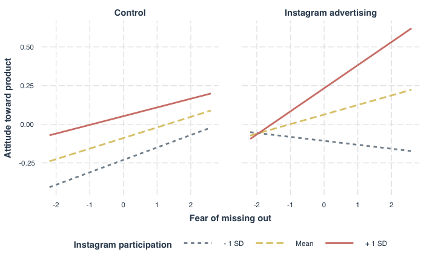

#### Regression: Primed individuals

```
Call:
lm(formula = attitude.constr_std ~ fomo.constr_std * participation.constr_std +
    popular_products.constr_std + online_shopping.constr_std +
    store_familiarity.constr_std + insta_attitude.constr_std +
    monstera_b + basil_b + artsy_b, data = dat_prime)

Residuals:
     Min       1Q   Median       3Q      Max
-3.06447 -0.45305  0.04675  0.53530  2.37138

Coefficients:
                                          Estimate Std. Error t value Pr(>|t|)
(Intercept)                               0.003246   0.080871   0.040  0.96800
fomo.constr_std                           0.055933   0.041959   1.333  0.18315
participation.constr_std                  0.155999   0.041763   3.735  0.00021 ***
popular_products.constr_std               0.086409   0.043681   1.978  0.04847 *
online_shopping.constr_std               -0.022207   0.041350  -0.537  0.59148
store_familiarity.constr_std              0.278420   0.040449   6.883 1.82e-11 ***
insta_attitude.constr_std                 0.066263   0.046989   1.410  0.15912
monstera_b                                0.083387   0.107717   0.774  0.43923
basil_b                                   0.293415   0.106846   2.746  0.00625 **
artsy_b                                  -0.238055   0.111873  -2.128  0.03385 *
fomo.constr_std:participation.constr_std  0.085968   0.034313   2.505  0.01256 *
---
Signif. codes:  0 ‘***’ 0.001 ‘**’ 0.01 ‘*’ 0.05 ‘.’ 0.1 ‘ ’ 1

Residual standard error: 0.8262 on 485 degrees of freedom
  (2 observations deleted due to missingness)
Multiple R-squared:  0.2621,    Adjusted R-squared:  0.2469
F-statistic: 17.23 on 10 and 485 DF,  p-value: < 2.2e-16

                         fomo.constr_std                 participation.constr_std              popular_products.constr_std               online_shopping.constr_std
                                1.294082                                 1.244435                                 1.351898                                 1.234247
            store_familiarity.constr_std                insta_attitude.constr_std                               monstera_b                                  basil_b
                                1.137231                                 1.523808                                 1.685423                                 1.673116
                                 artsy_b fomo.constr_std:participation.constr_std
                                1.599751                                 1.037513
```

##### Johnson-Neyman technique

```
JOHNSON-NEYMAN INTERVAL

When participation.constr_std is OUTSIDE the interval [-4.03, 0.32], the slope of fomo.constr_std is p < .05.

Note: The range of observed values of participation.constr_std is [-1.86, 2.16]
```

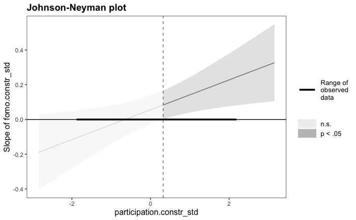

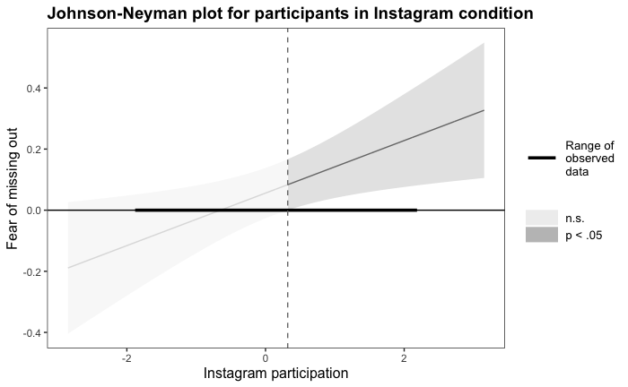

#### Regression: Not primed individuals

```
Call:
lm(formula = attitude.constr_std ~ fomo.constr_std * participation.constr_std +
    popular_products.constr_std + online_shopping.constr_std +
    store_familiarity.constr_std + insta_attitude.constr_std +
    monstera_b + basil_b + artsy_b, data = dat_noprime)

Residuals:
    Min      1Q  Median      3Q     Max
-3.3907 -0.4990  0.1171  0.6715  2.6645

Coefficients:
                                         Estimate Std. Error t value Pr(>|t|)
(Intercept)                               0.03405    0.09311   0.366 0.714731
fomo.constr_std                           0.07146    0.04843   1.476 0.140739
participation.constr_std                  0.15841    0.04821   3.286 0.001094 **
popular_products.constr_std               0.17749    0.04970   3.571 0.000392 ***
online_shopping.constr_std               -0.08280    0.04727  -1.752 0.080480 .
store_familiarity.constr_std              0.25978    0.04559   5.698 2.14e-08 ***
insta_attitude.constr_std                -0.02268    0.05227  -0.434 0.664564
monstera_b                               -0.22342    0.12449  -1.795 0.073333 .
basil_b                                   0.05918    0.12399   0.477 0.633363
artsy_b                                  -0.37312    0.13751  -2.713 0.006906 **
fomo.constr_std:participation.constr_std -0.01293    0.04215  -0.307 0.759212
---
Signif. codes:  0 ‘***’ 0.001 ‘**’ 0.01 ‘*’ 0.05 ‘.’ 0.1 ‘ ’ 1

Residual standard error: 0.9558 on 470 degrees of freedom
  (1 observation deleted due to missingness)
Multiple R-squared:  0.1775,    Adjusted R-squared:   0.16
F-statistic: 10.14 on 10 and 470 DF,  p-value: 1.64e-15

                         fomo.constr_std                 participation.constr_std              popular_products.constr_std               online_shopping.constr_std
                                1.223098                                 1.245276                                 1.333315                                 1.185844
            store_familiarity.constr_std                insta_attitude.constr_std                               monstera_b                                  basil_b
                                1.138538                                 1.515902                                 1.690568                                 1.690879
                                 artsy_b fomo.constr_std:participation.constr_std
                                1.501287                                 1.014778
```

##### Johnson-Neyman technique

```
JOHNSON-NEYMAN INTERVAL

The Johnson-Neyman interval could not be found. Is the p value for your interaction term below the specified alpha?
```

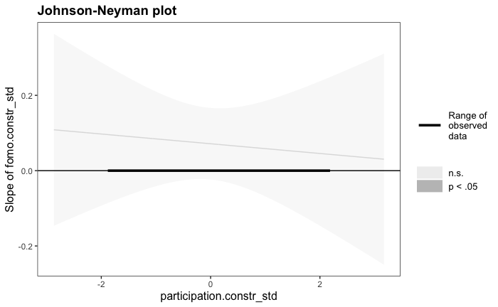

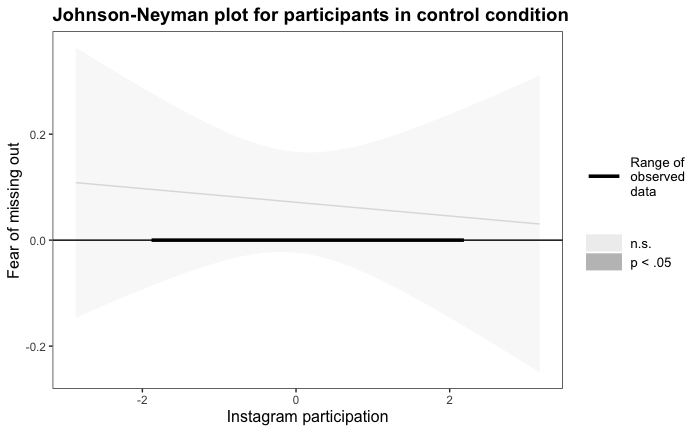

### Participation

```
Call:
lm(formula = participation.constr_std ~ popular_products.constr_std +
    online_shopping.constr_std + insta_attitude.constr_std, data = dat)

Residuals:
     Min       1Q   Median       3Q      Max
-2.63447 -0.62538  0.02396  0.60747  2.95259

Coefficients:
                             Estimate Std. Error t value Pr(>|t|)
(Intercept)                 0.0004452  0.0290810   0.015    0.988
popular_products.constr_std 0.0784471  0.0325116   2.413    0.016 *
online_shopping.constr_std  0.0138486  0.0308973   0.448    0.654
insta_attitude.constr_std   0.3786853  0.0314702  12.033   <2e-16 ***
---
Signif. codes:  0 ‘***’ 0.001 ‘**’ 0.01 ‘*’ 0.05 ‘.’ 0.1 ‘ ’ 1

Residual standard error: 0.9099 on 975 degrees of freedom
  (1 observation deleted due to missingness)
Multiple R-squared:  0.1746,    Adjusted R-squared:  0.1721
F-statistic: 68.75 on 3 and 975 DF,  p-value: < 2.2e-16
```